# Kmeans Clustering: Final Project

Carlos Pelayo

12/8/2019

```r
knitr::opts_chunk$set(echo = TRUE)
library(DMwR2)
library(cluster)
library(factoextra)
library(tidyverse)
```

# Unsupervised learning: cluster analysis

problem statiement: given a database of just over 400,000 transactions, each labeled as ‘ok’, ‘fraud’, or ‘unk’ use a machine learning technique to identify 50 or so transactions that *may* by fraudulent

## load the sales data set

notice that a variable was added: price per item

```r
data(sales)
salesDF = na.omit(sales)
salesDF$perItem = salesDF$Val/salesDF$Quant
salesDF$Quant = as.numeric(salesDF$Quant)
salesDF$Val = as.numeric(salesDF$Val)

head(salesDF)
```

```
## # A tibble: 6 x 6
##   ID    Prod  Quant   Val Insp  perItem
##   <fct> <fct> <dbl> <dbl> <fct>   <dbl>
## 1 v1    p1      182  1665 unkn     9.15
## 2 v2    p1     3072  8780 unkn     2.86
## 3 v3    p1    20393 76990 unkn     3.78
## 4 v4    p1      112  1100 unkn     9.82
## 5 v3    p1     6164 20260 unkn     3.29
## 6 v5    p2      104  1155 unkn    11.1
```

The sales data set consists of sale transaction reports. there are just over 400,000 transactions. The entries are

| Variable | Description |
| --- | --- |
| ID | employee ID number |
| Prod | product ID number |
| Quant | quantity sold |
| Val | reported value of the transaction |
| Insp | categorical variable: ‘ok’, ‘fraud’, ‘unkn’ |

Only a small percentage of the transactions have been verified as either ‘ok’ or ‘fraud.’ The purpose of the study is to Use cluser analysis to identify the top 50 ‘unkn’ transactions to be investigated for possible fraud

## Construct data set with ‘known’ transactions

This all transactions that are known to be either ‘ok’ or ‘fraud,’ look at the data

```r
fraudData = filter(salesDF, Insp=='fraud')
okData = filter(salesDF, Insp == 'ok')
fraud_ok = rbind(fraudData, okData)
```

### boxplots

notice that the range of data values is so large that log-transform was used

```r
nFraud = length(fraudData$Val)
print(nFraud)
```

```
## [1] 1199
```

```r
nOK = length(okData$Val)
print(nOK)
```

```
## [1] 14347
```

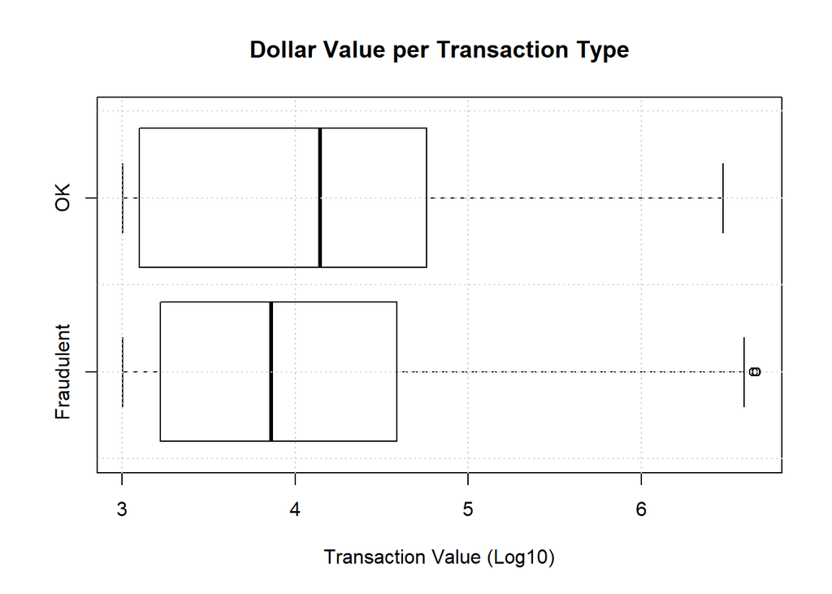

```r
names=c('Fraudulent','OK')
boxplot(log10(fraudData$Val),log10(okData$Val), names=names, horizontal = TRUE,
        main='Dollar Value per Transaction Type', xlab = 'Transaction Value (Log10)')
grid()
```

```r
summary(log10(fraudData$Val))
```

```
##    Min. 1st Qu.  Median    Mean 3rd Qu.    Max.
##   3.002   3.219   3.861   4.001   4.589   6.667
```

The above boxplot shows that both the fraud and ok transactions have about the same dollar distributions

By the the ‘per-item’ quantity

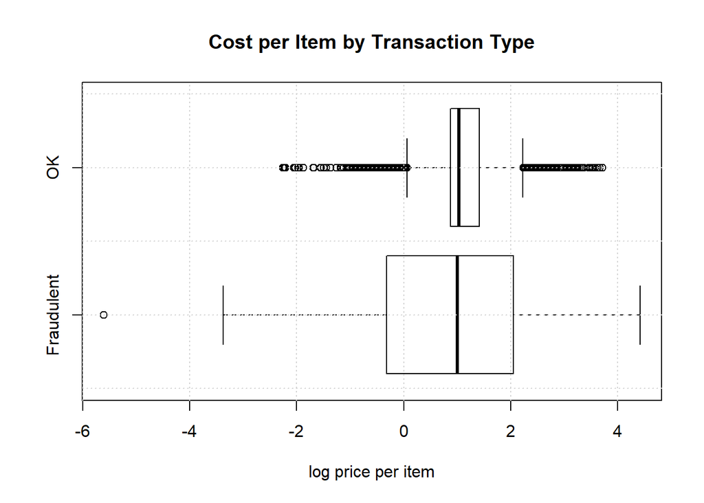

```r
boxplot(log10(fraudData$perItem), log10(okData$perItem), names=names, horizontal = TRUE, main='Cost per Item by Transaction Type', xlab = 'log price per item')
grid()
```

as may be expected the variability on fraudlent transactions is greater than that of the legit transactions

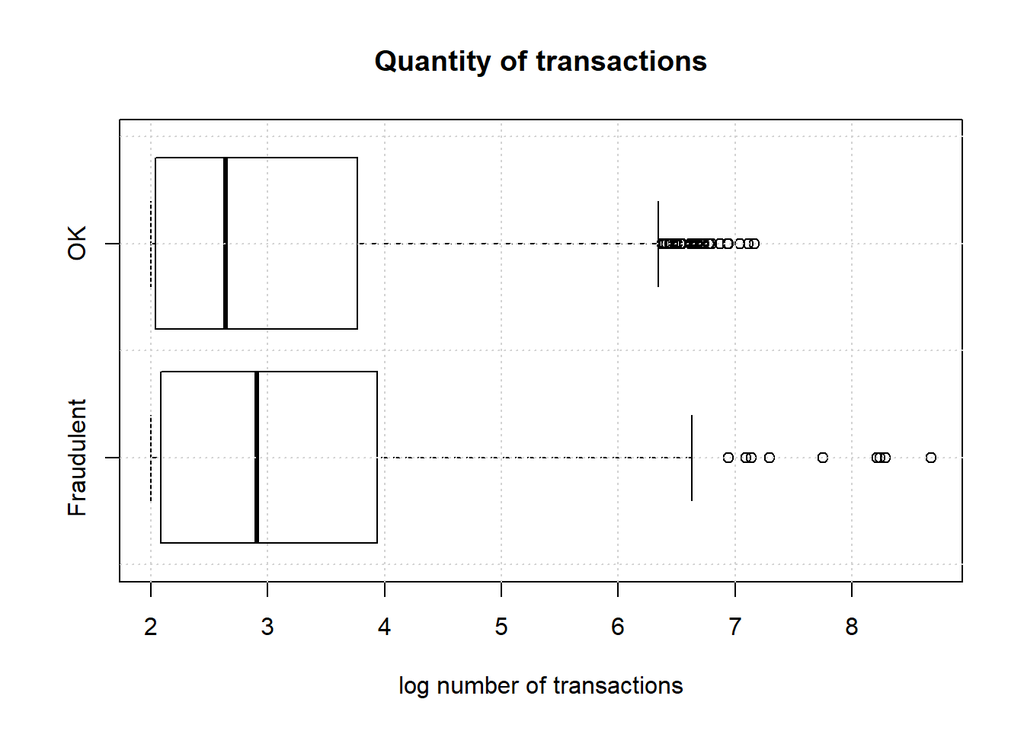

```r
boxplot(log10(fraudData$Quant), log10(okData$Quant), names=names, horizontal = TRUE, main='Quantity of transactions', xlab = 'log number of transactions')
grid()
```

boxplot shows little difference between the ‘ok’ and ‘fraud’ transactions. Larger orders could represent more of the fraudulent kind?

## set up data set for clustering;

This assumes that the variables are numeric, not categorical

```r
fraud_okLog = fraud_ok
fraud_okLog$Quant = log10(fraud_ok$Quant)
fraud_okLog$Val = log10(fraud_ok$Val)
fraud_okLog$perItem = log10(fraud_ok$perItem)
dfLog = fraud_okLog[,c(3,4,6)]
dfScaled = scale(fraud_ok[,c(3,4,6)])
```

## Try a few clusters

Multiple clusters…

```r
k2 =kmeans(dfScaled, centers=2, nstart=25)
k3= kmeans(dfScaled, centers=3, nstart=25)
k4= kmeans(dfScaled, centers=4, nstart=25)
k5= kmeans(dfScaled, centers=5, nstart=25)
k6= kmeans(dfScaled, centers=6, nstart=25)
```

plots to compare

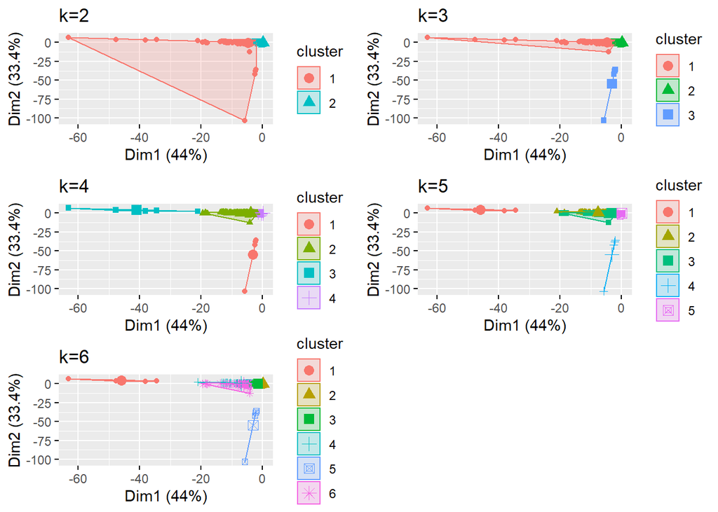

```r
p1 = fviz_cluster(k2, geom='point', data =dfScaled) + ggtitle('k=2')
p2 = fviz_cluster(k3, geom='point', data =dfScaled) + ggtitle('k=3')
p3 = fviz_cluster(k4, geom='point', data =dfScaled) + ggtitle('k=4')
p4 = fviz_cluster(k5, geom='point', data =dfScaled) + ggtitle('k=5')
p5 = fviz_cluster(k6, geom='point', data =dfScaled) + ggtitle('k=6')

library(gridExtra)
grid.arrange(p1, p2, p3, p4,p5,nrow=3)
```

## How many clusters?

look at the within cluster variability.

```r
was = function(k) {
  kmeans(dfScaled, centers=k, nstart=25)$tot.withinss
}

# compute and plot for k=1 to k=9
k.values=2:9

# extract was for 2-9 clusters
was.values = map_dbl(k.values, was)
print('silhouette values: ')
```

```
## [1] "silhouette values: "
```

```r
for (i in 2:9) print(paste(i," ", was.values[i]," ", was.values[i]/was.values[1]*100,"%"))
```

```
## [1] "2   24960.4654205025   67.5645894937351 %"
## [1] "3   15701.747897285   42.5024987772372 %"
## [1] "4   12527.4015838041   33.90997448059 %"
## [1] "5   10052.0161375644   27.209442311163 %"
## [1] "6   8781.69179135296   23.7708468551193 %"
## [1] "7   8002.35920616   21.6612994043573 %"
## [1] "8   7386.96523875595   19.9955115240391 %"
## [1] "9   NA   NA %"
```

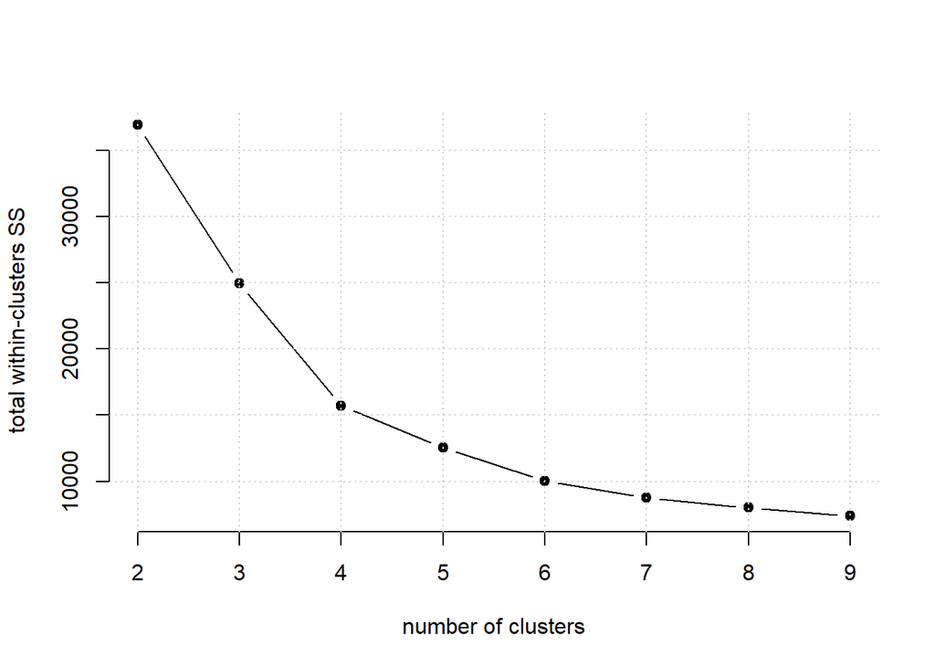

```r
plot(k.values, was.values, type='b', pch=19, frame=FALSE,
     xlab = 'number of clusters', ylab='total within-clusters SS')
grid()
```

## final result: clusters

larger ‘nstart’ means better chance of finding a *global* solution

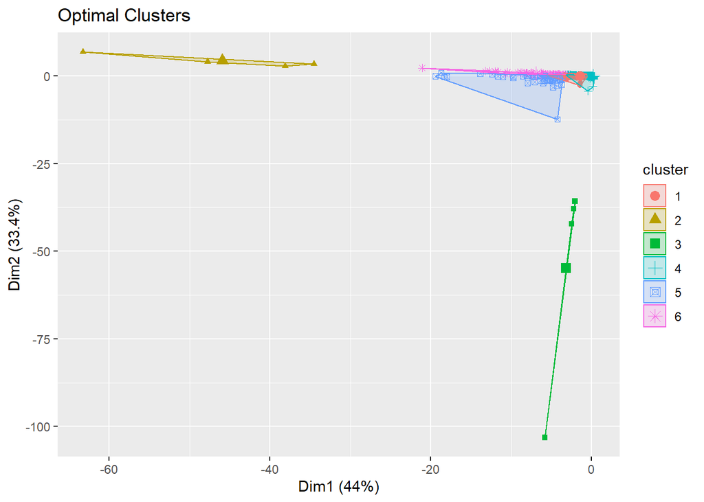

```r
final = kmeans(dfScaled,6, nstart=200)
fviz_cluster(final, geom='point', data = dfScaled) + ggtitle('Optimal Clusters')
```

### print cluster results:

```
## [1] "Cluster  4"
## [1] "fraud =  1094  ok =  13454"
## [1] " Cluster mean point"
## [1] "fraud =  8 %"
## [1] "-------"
## [1] "Cluster  1"
## [1] "fraud =  53  ok =  785"
## [1] " Cluster mean point"
## [1] "fraud =  6 %"
## [1] "-------"
## [1] "Cluster  6"
## [1] "fraud =  27  ok =  28"
## [1] " Cluster mean point"
## [1] "fraud =  49 %"
## [1] "-------"
```

[output cut: 19 more lines]

User centers of the ‘all fraud’ clusters to find transactions near these

```
## [1] "highest quantity sales"
```

```
## [1] "Person ID      quantity     type"
```

```
## [1] "v5733        473883883     fraud"
## [1] "v5458        194044544     fraud"
## [1] "v5458        173844544     fraud"
## [1] "v5458        164244544     fraud"
## [1] "v243        56590926     fraud"
## [1] "v4576        19708130     fraud"
## [1] "v3930        14645544     ok"
## [1] "v5458        13633433     fraud"
## [1] "v3930        12922666     ok"
## [1] "v243        12347577     fraud"
## [1] "v3930        11011711     ok"
## [1] "v5030        8782796     fraud"
## [1] "v3901        8718727     ok"
## [1] "v3901        8718727     ok"
## [1] "v3901        8718727     ok"
## [1] "v3901        8587988     ok"
## [1] "v3901        7377800     ok"
## [1] "v3901        7377800     ok"
## [1] "v3901        7377800     ok"
## [1] "v3901        6267322     ok"
```

```
## [1] "------------------------"
```

```
## [1] "highest price items"
```

```
## [1] "Person ID    item price    transaction"
```

```
## [1] "v1239     26460.7         fraud"
## [1] "v3599     16152.8279         fraud"
## [1] "v4577     13339.8693         fraud"
## [1] "v884     11297.1         fraud"
## [1] "v596     8755.9009         fraud"
## [1] "v1314     5431.4356         fraud"
## [1] "v4364     5255.3425         ok"
## [1] "v1255     5134.901         fraud"
## [1] "v54     4756.9595         fraud"
## [1] "v2948     4673.8298         ok"
## [1] "v2949     4653.9007         ok"
## [1] "v2948     4261.1852         ok"
## [1] "v884     3844.0989         fraud"
## [1] "v2956     3807.44         ok"
## [1] "v594     3755.7407         fraud"
## [1] "v5032     3577.9845         ok"
## [1] "v4448     3498.6066         fraud"
## [1] "v2956     3401.5984         ok"
## [1] "v2956     3386.1905         ok"
## [1] "v5032     3370.2344         ok"
```

## Find possible fraudlent transactions

```r
print(clusterCenterSave)
```

```
##             [,1]        [,2]       [,3]
## [1,] -0.02367144 17.45351790 47.6608432
## [2,] 54.98107421 -0.02799237 -0.1379266
```

```r
unkDataFrame = filter(salesDF, Insp == 'unkn')
nUnkn= length(unkDataFrame$ID)
```

find distances to ‘fraud’ clusters

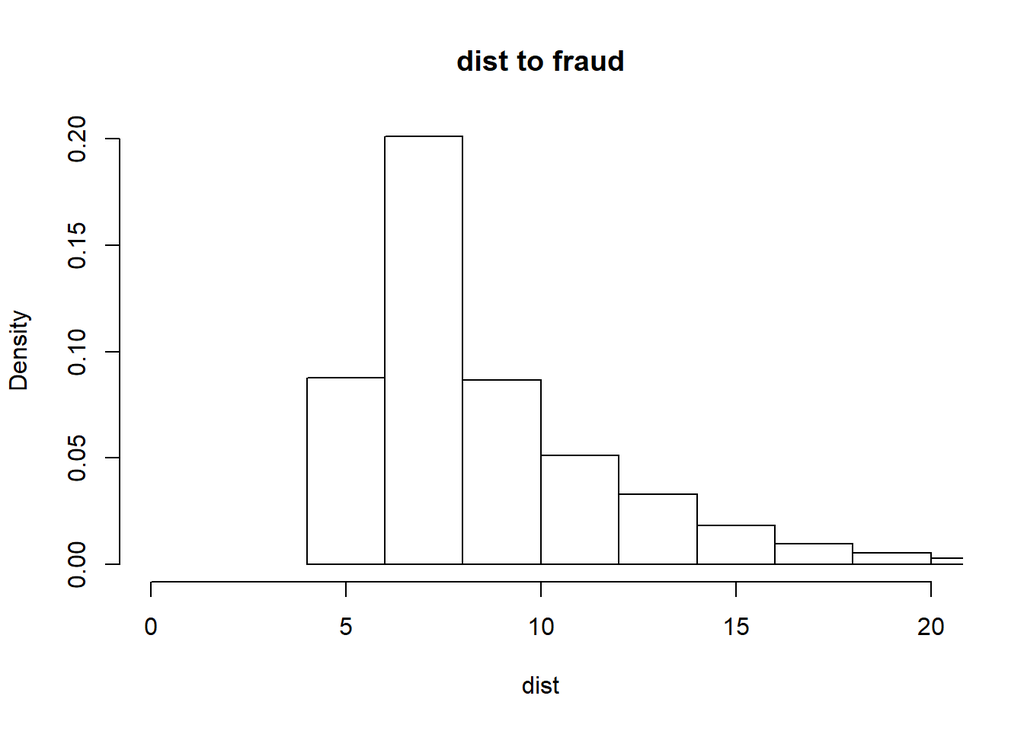

```r
saveTrans = matrix(data=0, nrow=nUnkn, ncol=2)
for(i in 1:nUnkn) {
  delta1 = c(as.numeric(unkDataFrame[i,c(3,4,6)])-as.numeric(clusterCenterSave[1,]))
  delta1 = sqrt(sum(delta1))
  delta2 = c(as.numeric(unkDataFrame[i,c(3,4,6)])-as.numeric(clusterCenterSave[2,]))
  delta2 = sqrt(sum(delta1))
saveTrans[i,]=c(i, min(delta1, delta2))

}
hist(saveTrans[,2],xlim=c(0,20), main="dist to fraud", xlab='dist', freq=FALSE)
```

```r
sortSaveTrans = sort(saveTrans[,1], index.return=TRUE)

print(unkDataFrame[sortSaveTrans$ix[1:100],])
```

```
## # A tibble: 100 x 6
##    ID    Prod  Quant   Val Insp  perItem
##    <fct> <fct> <dbl> <dbl> <fct>   <dbl>
##  1 v1    p1      182  1665 unkn     9.15
##  2 v2    p1     3072  8780 unkn     2.86
##  3 v3    p1    20393 76990 unkn     3.78
##  4 v4    p1      112  1100 unkn     9.82
##  5 v3    p1     6164 20260 unkn     3.29
##  6 v5    p2      104  1155 unkn    11.1
##  7 v6    p2      350  5680 unkn    16.2
##  8 v7    p2      200  4010 unkn    20.0
##  9 v8    p2      233  2855 unkn    12.3
## 10 v9    p2      118  1175 unkn     9.96
## # ... with 90 more rows
```

```r
print(unique(unkDataFrame[sortSaveTrans$ix[1:100],]$ID))
```

```
##  [1] v1  v2  v3  v4  v5  v6  v7  v8  v9  v10 v12 v13 v14 v15 v16 v17 v18
## [18] v20 v21 v22 v23 v24 v25 v26 v27 v28 v29 v30 v31 v33 v34 v35 v36 v38
## [35] v39 v40 v41 v43 v44 v45 v46 v42 v47 v48 v49 v50 v51 v52 v53
## 6016 Levels: v1 v2 v3 v4 v5 v6 v7 v8 v9 v10 v11 v12 v13 v14 v15 v16 ... v6070
```